# BlogEntry3

Zachary Palmore

5/18/2021

```r
library(dplyr)
library(ggplot2)
library(tidyr)
```

## Multivariate Linearity for Multiple Linear Regression

When building a multiple linear regression model there are four main assumptions that we make in order to make accurate predictions. They are the independence of events, presence of homoscedasticity, normality, and linearity. For this week’s post we are going to focus on that last assumption we listed, linearity. For linear regression, it is imperative that we understand the kind of patterns the data fits to explain or predict with, otherwise we may be assuming the data is linear when in fact they are not!

To begin, we consider a scenario in which a state government wants to ascertain the conditions of its living fish stock. Their game and wildlife management departments would like to know what size fish would be suitable for public consumption since there is a known containment present in species of chain pickerel. At this time, they are unable to classify it as harmful to humans but would like to assess the population before any issues arise. This data is based on New York State’s chain pickerel measurements caught by conservationists working with the department.

```r
cp <- read.csv("https://raw.githubusercontent.com/palmorezm/misc/master/Pickerel.csv")
colnames(cp) <- c("SampleID", "Length", "Weight", "Minutes", "Hook","Tissue","Strength","Depth","O2", "PPM","Species")
head(cp)
```

```
##   SampleID Length Weight Minutes Hook Tissue  Strength     Depth     O2   PPM
## 1     7141     18     20     545    3      9  36.03159 10900.171 26.004 4.135
## 2     7369     25     58     679    4     28  59.80888 39382.366 35.950 3.420
## 3     6070     21     33     741    4      7  47.43589 24453.313 30.838 2.105
## 4     8664     21     33     257    1      3  44.66198  8481.636 27.838 3.045
## 5     2396     18     20     103    7      5  31.68544  2060.261 30.004 1.075
## 6     3347     31    126      45    6     90 127.40246  5670.662 45.618 4.350
##          Species
## 1 Chain Pickerel
## 2 Chain Pickerel
## 3 Chain Pickerel
## 4 Chain Pickerel
## 5 Chain Pickerel
## 6 Chain Pickerel
```

```r
sel <- cp %>%
  select(SampleID, Length, Weight, Tissue, Strength, Depth, O2, PPM)
sel <- data.frame(lapply(sel, as.numeric))
```

To determine which of these variables follow a linear pattern and could be used in linear regression, we simply plot them as scatterplot and format them in a matrix. The variable names are listed in the boxes in the center of the matrix. Scatterplots to the right and left of these labels are mirror images of one another.

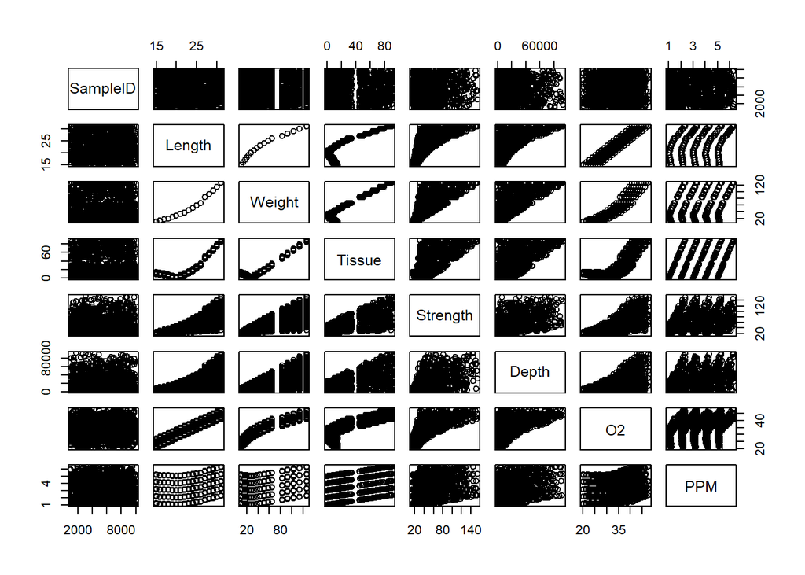

```r
plot(sel)
```

It is a little crowded and difficult to interpret in this way. We need to find at least one variable to exclude to improve this matrix. Based on the almost entirely darkly covered scatterplots for each SampleID and selected variable, it is clear there is little to no relationship at all. The data is randomly distributed throughout their respective plots and this is to be expected. The SampleID is a randomly assigned value to record the observation as a unique case. Thus, we remove it.

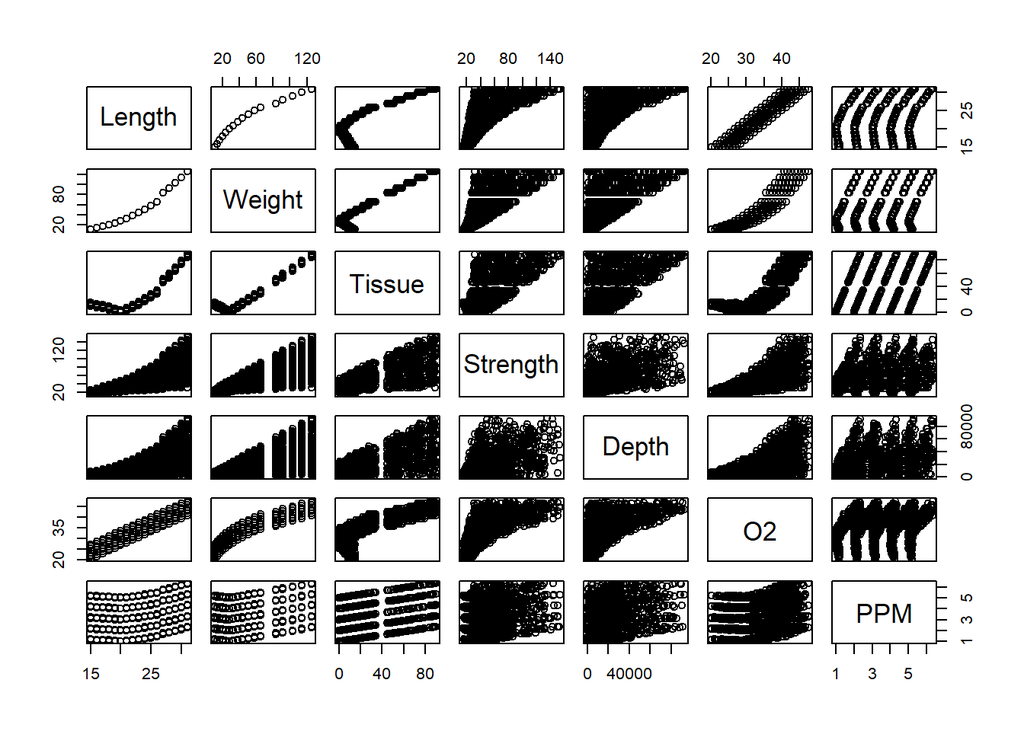

```r
plot(sel[2:8])
```

With this clearer view we now have a better idea of the relationships between the variables. However, there are only three seemingly distinct linear patterns. When we identify linearity, we look for a steady, stable, increase or decrease in the dependent variable as the independent increases. Weight appears to have a steady increase as length increases, but it is not a perfectly straight line. We consider other variables as well.